# Assignment 4 : Building Features, Watching What Happens

- Show All Code
- Hide All Code
- View Source

MUSA 5080 · Integrates Weeks 1–5

Author

RYSKA

Published

October 16, 2026

## Part 0: Setup

```r
library(tidyverse)
library(tidycensus)
library(sf)
library(caret)

Sys.getenv("CENSUS_API_KEY") != ""
```

```
[1] TRUE
```

### The cross-validation helper

```r
ctrl <- trainControl(method = "cv", number = 10)

cv_rmse <- function(formula, data) {
  df <- if (inherits(data, "sf")) st_drop_geometry(data) else data
  vars <- all.vars(formula)
  bad <- vars[sapply(vars, function(v) any(is.na(df[[v]])))]
  if (length(bad) > 0) {
    stop("These variables have NAs: ", paste(bad, collapse = ", "),
         ". Fill them or choose another variable (Rule 1: don't drop rows).")
  }
  set.seed(5080)
  fit <- train(formula, data = df, method = "lm", trControl = ctrl)
  fit$results$RMSE
}
```

### The model log

```r
model_log <- tibble(
  model   = character(),
  added   = character(),
  cv_rmse = numeric(),
  notes   = character()
)
```

## Part 1: Outcome -> % of people below poverty

Understanding poverty in Philadelphia areas and how some variable related to it will help policymakers allocate resources, develop targeted programs, and create policies to improve quality of life.

### 1A: Pulling outcome and baseline predictors

**Baseline predictors**

Educational attainment less than highschool

Number of household that have 4 or more people

Median age

```r
philly_tracts <- get_acs(
  geography = "tract",
  state = "PA",
  county = "Philadelphia",
  variables = c(
    total_pop = "B01003_001",
    below_pov = "B07012_002",
    less_highschool = "B23006_002",
    hhsize_4andmore = "B08201_025",
    median_age = "B06002_001"
  ),
  year = 2023,
  output = "wide",
  progress = FALSE,
  geometry = TRUE
) %>%
  st_transform(2272)
```

```r
philly_tracts <- philly_tracts %>%
  mutate(
    # build your outcome, e.g. a percentage:
    y = below_povE / total_popE * 100,
    # and its reliability. For a percentage, use tidycensus::moe_prop();
    # for a median or count, use the E and M columns directly.
    y_moe = moe_prop(below_povE, total_popE,
                         below_povM, total_popM),
    y_cv  = (y_moe / 1.645) / y * 100,
    # your predictors:
    less_hschool = less_highschoolE,
    hhsize_4more = hhsize_4andmoreE,
    med_age = median_ageE
  )
```

### 1B: Checking reliability

```r
# How many tracts have no value for your outcome?
sum(is.na(philly_tracts$y))
```

```
[1] 17
```

```r
# How reliable is it?
summary(philly_tracts$y_cv)
```

```
   Min. 1st Qu.  Median    Mean 3rd Qu.    Max.     NAs
0.06663 0.22756 0.28213     Inf 0.35563     Inf      17
```

```r
philly_tracts %>%
  mutate(reliability = case_when(
    y_cv < 12  ~ "High",
    y_cv <= 40 ~ "Moderate",
    TRUE       ~ "Low"
  )) %>%
  st_drop_geometry() %>%
  count(reliability)
```

```
  reliability   n
1        High 388
2         Low  20
```

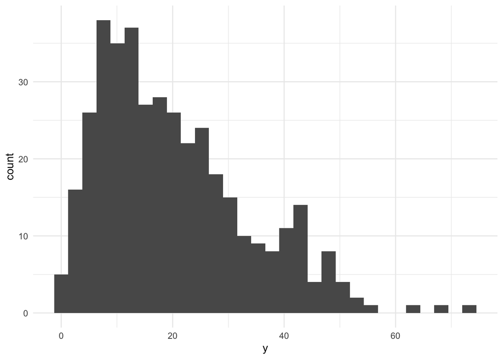

```r
# What does the distribution look like?
ggplot(philly_tracts, aes(x = y)) +
  geom_histogram(bins = 30) +
  theme_minimal()
```

For % of people below poverty outcome, 388 tracts (95%) is in high reliability and 20 tracts is low.

### 1C: Decide which tracts to model

```r
tracts <- philly_tracts %>%
  filter(total_popE > 0,
         !is.na(y)
         # add !is.na() for each baseline predictor like in the in-class lab
         )

nrow(philly_tracts)
```

```
[1] 408
```

```r
nrow(tracts)
```

```
[1] 391
```

There are 17 census tract that have no population, those census tracts are airports, parks, stadiums, industrial, or special use areas

## Part 2: Baseline model

### 2A: Look first

Plot your outcome against each predictor before modeling.

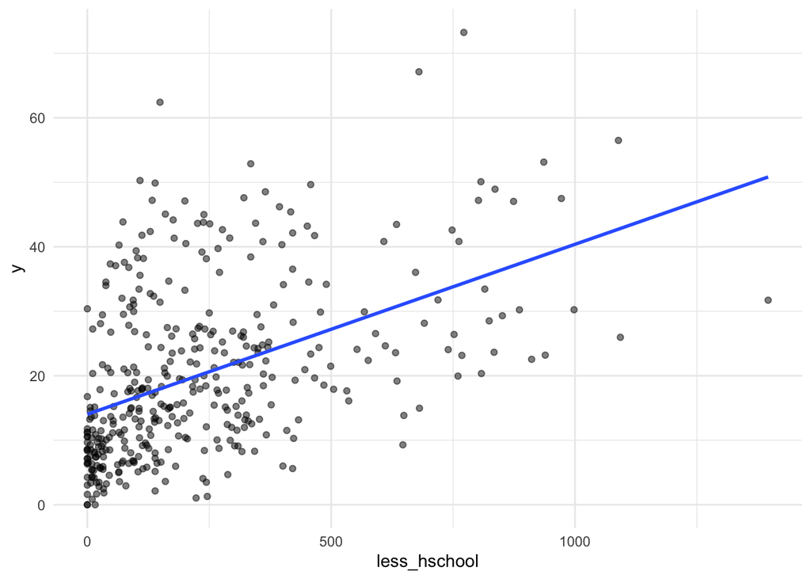

```r
# one scatterplot per predictor, e.g.:
ggplot(tracts, aes(x = less_hschool, y = y)) + geom_point(alpha = 0.5) +
  geom_smooth(method = "lm", se = FALSE) + theme_minimal()
```

### 2B: Fit and log

```r
f1 <- y ~ less_hschool + hhsize_4more + med_age

m1 <- lm(f1, data = tracts)
summary(m1)
```

```
Call:
lm(formula = f1, data = tracts)

Residuals:
    Min      1Q  Median      3Q     Max
-27.203  -7.969  -2.456   5.635  39.580

Coefficients:
              Estimate Std. Error t value Pr(>|t|)
(Intercept)  29.885423   3.011284   9.924  < 2e-16 ***
less_hschool  0.030735   0.003344   9.192  < 2e-16 ***
hhsize_4more -0.008745   0.003589  -2.437   0.0153 *
med_age      -0.387674   0.074947  -5.173 3.71e-07 ***
---
Signif. codes:  0 '***' 0.001 '**' 0.01 '*' 0.05 '.' 0.1 ' ' 1

Residual standard error: 11.34 on 387 degrees of freedom
Multiple R-squared:  0.2754,    Adjusted R-squared:  0.2698
F-statistic: 49.03 on 3 and 387 DF,  p-value: < 2.2e-16
```

```r
model_log <- model_log %>%
  add_row(model = "m1", added = "ACS baseline",
          cv_rmse = cv_rmse(f1, tracts),
          notes = "Baseline with ACS Variables")

model_log
```

```
# A tibble: 1 × 4
  model added        cv_rmse notes
  <chr> <chr>          <dbl> <chr>
1 m1    ACS baseline    11.3 Baseline with ACS Variables
```

On tracts it hasn’t seen, the baseline model misses by about 11.35

### 2C: Where is the baseline wrong?

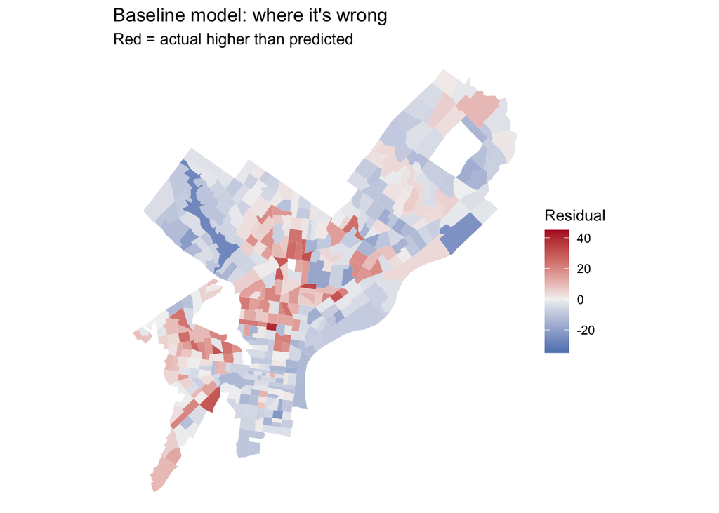

```r
tracts <- tracts %>% mutate(resid_m1 = residuals(m1))

map_baseline <- ggplot(tracts) +
  geom_sf(aes(fill = resid_m1), color = NA) +
  scale_fill_gradient2(low = "#2166ac", mid = "grey95", high = "#b2182b", midpoint = 0, limits = c(-35, 45)) +
  theme_void() +
  labs(title = "Baseline model: where it's wrong",
       subtitle = "Red = actual higher than predicted",
       fill = "Residual")

map_baseline
```

## Part 3: Getting data from Philadelphia’s open data portal

```r
carto_get <- function(sql) {
  url <- paste0("https://phl.carto.com/api/v2/sql?format=GeoJSON&q=", URLencode(sql))
  st_read(url, quiet = TRUE)
}
```

### Finding a table name

On a dataset’s OpenDataPhilly page, look for the API link. The table name is the word after `FROM` in the example query. To see what values a column takes before you filter on it, ask for a count in CSV format:

```r
# What kinds of crime are in the incidents table in 2023?
url <- paste0("https://phl.carto.com/api/v2/sql?format=csv&q=",
              URLencode("SELECT text_general_code, COUNT(*) AS n
                         FROM incidents_part1_part2
                         WHERE dispatch_date >= '2023-01-01' AND dispatch_date < '2024-01-01'
                         GROUP BY text_general_code ORDER BY n DESC"))
read_csv(url)
```

```
# A tibble: 32 × 2
   text_general_code                 n
   <chr>                         <dbl>
 1 Thefts                        37054
 2 Other Assaults                25986
 3 Motor Vehicle Theft           22478
 4 Vandalism/Criminal Mischief   17346
 5 All Other Offenses            13334
 6 Theft from Vehicle            13002
 7 Fraud                          7661
 8 Aggravated Assault No Firearm  5134
 9 Burglary Residential           3800
10 Aggravated Assault Firearm     3320
# ℹ 22 more rows
```

Based on the gaps identified from part 2C, thefts and bus stops layer will be added.

```r
thefts <- carto_get(
  "SELECT the_geom, text_general_code, dispatch_date
   FROM incidents_part1_part2
   WHERE dispatch_date >= '2023-01-01' AND dispatch_date < '2024-01-01'
  AND text_general_code = 'Thefts'"
) %>%
  st_transform(st_crs(tracts))
nrow(thefts)
```

```
[1] 37054
```

```r
thefts_clean <- filter(thefts, !st_is_empty(thefts))
nrow(thefts_clean)
```

```
[1] 35467
```

```r
busstop <- st_read(
  "https://hub.arcgis.com/api/v3/datasets/4face8b41aa145d4b3899528e0f8488b_0/downloads/data?format=geojson&spatialRefId=4326&where=1%3D1") %>%
  st_transform(st_crs(tracts))
nrow(busstop)
```

```
[1] 20441
```

```r
busstop_clean <- filter(busstop, !st_is_empty(busstop))
nrow(busstop_clean)
```

```
[1] 20441
```

**Thefts** and **bus stops** connect to poverty because they reflect area conditions that tend to go along with it. Areas with concentrated disadvantage often have more property crime, and lower-income households rely more on buses, so transit coverage is denser where they live.

There era 1587 (4%) thefts data that have no location and will be dropped for this assessment.

## Part 4: Building spatial features

### 4A: Bus Stops, number and density

```r
tracts <- tracts %>%
  mutate(
    n_busstop = lengths(st_intersects(., busstop)),
    area_sqmi  = as.numeric(st_area(.)) / 27878400,   # sq ft in a sq mile
    busstop_per_sqmi = n_busstop / area_sqmi)

summary(tracts$n_busstop)
```

```
   Min. 1st Qu.  Median    Mean 3rd Qu.    Max.
   0.00   15.00   26.00   31.67   43.00  181.00
```

```r
f2 <- y ~ less_hschool + hhsize_4more + med_age + n_busstop

model_log <- model_log %>%
  add_row(model = "m2", added = "# Bus Stops",
          cv_rmse = cv_rmse(f2, tracts),
          notes = "Number of Bus Stops")
model_log
```

```
# A tibble: 2 × 4
  model added        cv_rmse notes
  <chr> <chr>          <dbl> <chr>
1 m1    ACS baseline    11.3 Baseline with ACS Variables
2 m2    # Bus Stops     11.3 Number of Bus Stops
```

```r
f3 <- y ~ less_hschool + hhsize_4more + med_age + busstop_per_sqmi

model_log <- model_log %>%
  add_row(model = "m3", added = "Bus Stop Density",
          cv_rmse = cv_rmse(f3, tracts),
          notes = "Bus stop per sqmi")
model_log
```

```
# A tibble: 3 × 4
  model added            cv_rmse notes
  <chr> <chr>              <dbl> <chr>
1 m1    ACS baseline        11.3 Baseline with ACS Variables
2 m2    # Bus Stops         11.3 Number of Bus Stops
3 m3    Bus Stop Density    11.4 Bus stop per sqmi
```

### 4B: Thefts, number and density

```r
tracts <- tracts %>%
  mutate(n_thefts = lengths(st_intersects(., thefts_clean)))

summary(tracts$n_thefts)
```

```
   Min. 1st Qu.  Median    Mean 3rd Qu.    Max.
   2.00   34.00   57.00   87.17  103.50  934.00
```

```r
tracts <- tracts %>%
  mutate(
    area_sqmi         = as.numeric(st_area(.)) / 27878400,   # sq ft in a sq mile
    thefts_per_sqmi = n_thefts / area_sqmi,
    thefts_per_1k   = n_thefts / total_popE * 1000,
  )

f4 <- y ~ less_hschool + hhsize_4more + med_age + n_thefts

model_log <- model_log %>%
  add_row(model = "m4", added = "# Thefts",
          cv_rmse = cv_rmse(f4, tracts),
          notes = "Number of thefts")
model_log
```

```
# A tibble: 4 × 4
  model added            cv_rmse notes
  <chr> <chr>              <dbl> <chr>
1 m1    ACS baseline        11.3 Baseline with ACS Variables
2 m2    # Bus Stops         11.3 Number of Bus Stops
3 m3    Bus Stop Density    11.4 Bus stop per sqmi
4 m4    # Thefts            11.4 Number of thefts
```

```r
f5 <- y ~ less_hschool + hhsize_4more + med_age + thefts_per_1k

model_log <- model_log %>%
  add_row(model = "m5", added = "Thefts Density",
          cv_rmse = cv_rmse(f5, tracts),
          notes = "Thefts per 1000 Population")
model_log
```

```
# A tibble: 5 × 4
  model added            cv_rmse notes
  <chr> <chr>              <dbl> <chr>
1 m1    ACS baseline        11.3 Baseline with ACS Variables
2 m2    # Bus Stops         11.3 Number of Bus Stops
3 m3    Bus Stop Density    11.4 Bus stop per sqmi
4 m4    # Thefts            11.4 Number of thefts
5 m5    Thefts Density      11.3 Thefts per 1000 Population
```

### 4C: Measuring distance to City Hall

Distance to City Hall shows how close a tract is to the city center, and this relates to poverty because location affects housing costs, access to jobs, and how an area developed over time.

```r
city_hall <- st_sfc(st_point(c(-75.1636, 39.9526)), crs = 4326) %>%
  st_transform(st_crs(tracts))

tract_pts <- st_point_on_surface(tracts)   # always inside the tract, unlike a centroid

tracts <- tracts %>%
  mutate(dist_ch_mi = as.numeric(st_distance(tract_pts, city_hall)) / 5280)

f6 <- y ~ less_hschool + hhsize_4more + med_age + dist_ch_mi

model_log <- model_log %>%
  add_row(model = "m6", added = "Distance to City Hall",
          cv_rmse = cv_rmse(f6, tracts),
          notes = "Distance to City Hall")

# repeat for each feature
model_log
```

```
# A tibble: 6 × 4
  model added                 cv_rmse notes
  <chr> <chr>                   <dbl> <chr>
1 m1    ACS baseline             11.3 Baseline with ACS Variables
2 m2    # Bus Stops              11.3 Number of Bus Stops
3 m3    Bus Stop Density         11.4 Bus stop per sqmi
4 m4    # Thefts                 11.4 Number of thefts
5 m5    Thefts Density           11.3 Thefts per 1000 Population
6 m6    Distance to City Hall    11.2 Distance to City Hall
```

Distance to City Hall helped the most. It lowered the cross-validated RMSE about 0.13. number of bus stops (11.334) and thefts density (11.336) each improved it by only about 0.015, which is a very small change. On the other hand, bus stop density and number of theft worsen the model.

Adding thefts and bus stops only slightly improve the model, it might be because of thefts and bus stops also affected by the area characteristic that serves as destination so they do not completely reflect the residents, for example busy areas like Center City can have many thefts and stops because it is destination area.

## Part 5: Transforming features

**log thefts density**

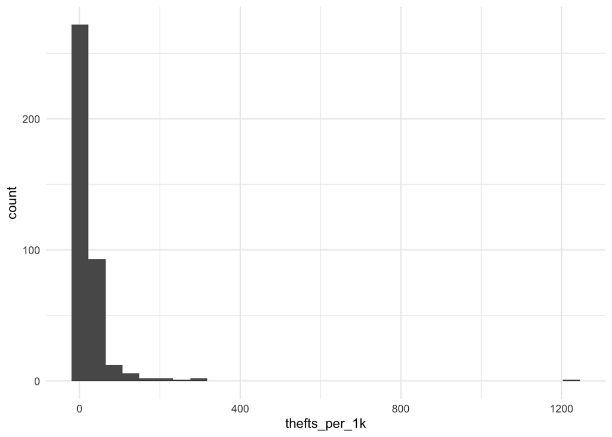

```r
#log

ggplot(tracts, aes(x = thefts_per_1k)) + geom_histogram(bins = 30) + theme_minimal()
```

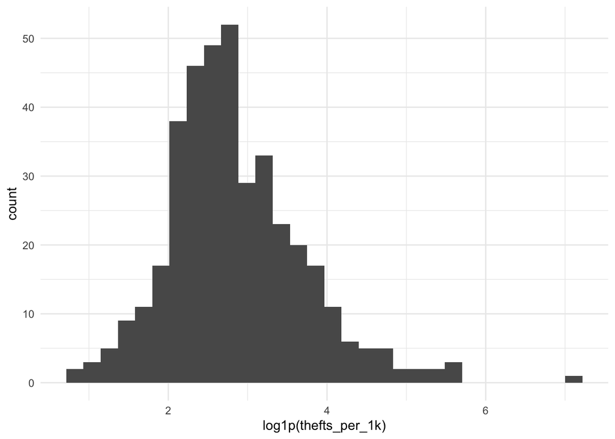

```r
ggplot(tracts, aes(x = log1p(thefts_per_1k))) + geom_histogram(bins = 30) + theme_minimal()
```

```r
f_log <- y ~ less_hschool + hhsize_4more + med_age + log1p(thefts_per_1k)

model_log <- model_log %>%
  add_row(model = "m7", added = "log of thefts density",
          cv_rmse = cv_rmse(f_log, tracts),
          notes = "log of thefts per 1k population")
model_log
```

```
# A tibble: 7 × 4
  model added                 cv_rmse notes
  <chr> <chr>                   <dbl> <chr>
1 m1    ACS baseline             11.3 Baseline with ACS Variables
2 m2    # Bus Stops              11.3 Number of Bus Stops
3 m3    Bus Stop Density         11.4 Bus stop per sqmi
4 m4    # Thefts                 11.4 Number of thefts
5 m5    Thefts Density           11.3 Thefts per 1000 Population
6 m6    Distance to City Hall    11.2 Distance to City Hall
7 m7    log of thefts density    11.4 log of thefts per 1k population
```

**squared term of distance to city hall**

```r
# squared term
m_sq <- lm(y ~ dist_ch_mi + I(dist_ch_mi^2), data = tracts)
summary(m_sq)
```

```
Call:
lm(formula = y ~ dist_ch_mi + I(dist_ch_mi^2), data = tracts)

Residuals:
    Min      1Q  Median      3Q     Max
-23.161 -10.142  -1.697   6.824  50.221

Coefficients:
                Estimate Std. Error t value Pr(>|t|)
(Intercept)     16.35639    1.72937   9.458  < 2e-16 ***
dist_ch_mi       2.71633    0.62732   4.330 1.90e-05 ***
I(dist_ch_mi^2) -0.26937    0.04718  -5.710 2.25e-08 ***
---
Signif. codes:  0 '***' 0.001 '**' 0.01 '*' 0.05 '.' 0.1 ' ' 1

Residual standard error: 12.58 on 388 degrees of freedom
Multiple R-squared:  0.1061,    Adjusted R-squared:  0.1015
F-statistic: 23.02 on 2 and 388 DF,  p-value: 3.568e-10
```

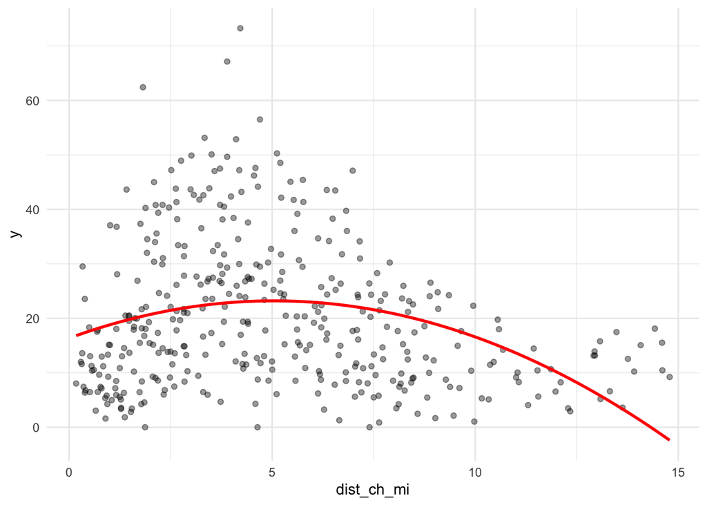

```r
ggplot(tracts, aes(x = dist_ch_mi, y = y)) +
  geom_point(alpha = 0.4) +
  geom_smooth(method = "lm", formula = y ~ x + I(x^2), se = FALSE, color = "red") +
  theme_minimal()
```

```r
f_sq <- y ~ less_hschool + hhsize_4more + med_age + dist_ch_mi + I(dist_ch_mi^2)

model_log <- model_log %>%
  add_row(model = "m8", added = "squared distance to city hall",
          cv_rmse = cv_rmse(f_sq, tracts),
          notes = "squared distance to city hall")
model_log
```

```
# A tibble: 8 × 4
  model added                         cv_rmse notes
  <chr> <chr>                           <dbl> <chr>
1 m1    ACS baseline                     11.3 Baseline with ACS Variables
2 m2    # Bus Stops                      11.3 Number of Bus Stops
3 m3    Bus Stop Density                 11.4 Bus stop per sqmi
4 m4    # Thefts                         11.4 Number of thefts
5 m5    Thefts Density                   11.3 Thefts per 1000 Population
6 m6    Distance to City Hall            11.2 Distance to City Hall
7 m7    log of thefts density            11.4 log of thefts per 1k population
8 m8    squared distance to city hall    11.1 squared distance to city hall
```

**categorical distance to city hall**

```r
# categorical

tracts <- tracts %>%
  mutate(
    ring = case_when(
      dist_ch_mi < 2 ~ "Core",
      dist_ch_mi < 5 ~ "Inner",
      TRUE           ~ "Outer"
    ),
    ring = factor(ring, levels = c("Core", "Inner", "Outer"))
  )

tracts %>% st_drop_geometry() %>% count(ring)
```

```
   ring   n
1  Core  81
2 Inner 137
3 Outer 173
```

```r
m_cat <- lm(y ~ less_hschool + hhsize_4more + med_age + ring, data = tracts)
summary(m_cat)
```

```
Call:
lm(formula = y ~ less_hschool + hhsize_4more + med_age + ring,
    data = tracts)

Residuals:
    Min      1Q  Median      3Q     Max
-26.158  -7.511  -1.685   4.966  43.859

Coefficients:
              Estimate Std. Error t value Pr(>|t|)
(Intercept)  24.563778   2.998010   8.193 3.80e-15 ***
less_hschool  0.027097   0.003245   8.352 1.23e-15 ***
hhsize_4more -0.007610   0.003689  -2.063   0.0398 *
med_age      -0.333941   0.076269  -4.378 1.54e-05 ***
ringInner     8.681885   1.599052   5.429 1.00e-07 ***
ringOuter     1.838978   1.665638   1.104   0.2703
---
Signif. codes:  0 '***' 0.001 '**' 0.01 '*' 0.05 '.' 0.1 ' ' 1

Residual standard error: 10.8 on 385 degrees of freedom
Multiple R-squared:  0.3456,    Adjusted R-squared:  0.3371
F-statistic: 40.67 on 5 and 385 DF,  p-value: < 2.2e-16
```

```r
f_cat <- y ~ less_hschool + hhsize_4more + med_age + ring

model_log <- model_log %>%
  add_row(model = "m9", added = "categorical distance to city hall",
          cv_rmse = cv_rmse(f_cat, tracts),
          notes = "categorical distance to city hall")
model_log
```

```
# A tibble: 9 × 4
  model added                             cv_rmse notes
  <chr> <chr>                               <dbl> <chr>
1 m1    ACS baseline                         11.3 Baseline with ACS Variables
2 m2    # Bus Stops                          11.3 Number of Bus Stops
3 m3    Bus Stop Density                     11.4 Bus stop per sqmi
4 m4    # Thefts                             11.4 Number of thefts
5 m5    Thefts Density                       11.3 Thefts per 1000 Population
6 m6    Distance to City Hall                11.2 Distance to City Hall
7 m7    log of thefts density                11.4 log of thefts per 1k populati…
8 m8    squared distance to city hall        11.1 squared distance to city hall
9 m9    categorical distance to city hall    10.9 categorical distance to city …
```

The categorical distance to City Hall (m9) helped most, lowering the cross-validated RMSE from 11.35 (ACS baseline) to 10.86. The squared distance (m8, 11.10) was second, and the log of thefts density (m7, 11.35) did not help at all.

In categorical distance to city hall, core is the reference level. Holding the ACS baseline variable constant, tracts in the inner ring (2 to 5 miles from City Hall) have a predicted poverty rate about 8.7 percentage points higher than tracts in the core (within 2 miles), and uuter tracts are about 1.8 points higher than core tracts.

## Part 6: Final model

```r
f_final <- y ~ less_hschool + hhsize_4more + med_age + ring + thefts_per_1k + n_busstop

m_final <- lm(f_final, data = tracts)
summary(m_final)
```

```
Call:
lm(formula = f_final, data = tracts)

Residuals:
    Min      1Q  Median      3Q     Max
-26.277  -7.301  -1.693   5.136  43.943

Coefficients:
               Estimate Std. Error t value Pr(>|t|)
(Intercept)   25.088580   3.029485   8.281 2.06e-15 ***
less_hschool   0.027110   0.003252   8.337 1.39e-15 ***
hhsize_4more  -0.007674   0.003733  -2.056   0.0405 *
med_age       -0.320033   0.077615  -4.123 4.58e-05 ***
ringInner      8.477140   1.608468   5.270 2.28e-07 ***
ringOuter      1.777045   1.691127   1.051   0.2940
thefts_per_1k -0.007454   0.008162  -0.913   0.3617
n_busstop     -0.022466   0.025051  -0.897   0.3704
---
Signif. codes:  0 '***' 0.001 '**' 0.01 '*' 0.05 '.' 0.1 ' ' 1

Residual standard error: 10.8 on 383 degrees of freedom
Multiple R-squared:  0.3491,    Adjusted R-squared:  0.3372
F-statistic: 29.34 on 7 and 383 DF,  p-value: < 2.2e-16
```

```r
model_log <- model_log %>%
  add_row(model = "final", added = "ACS baseline plus added variables",
          cv_rmse = cv_rmse(f_final, tracts),
          notes = "ACS baseline plus the lowest rmse for each added categorical form")

model_log
```

```
# A tibble: 10 × 4
   model added                             cv_rmse notes
   <chr> <chr>                               <dbl> <chr>
 1 m1    ACS baseline                         11.3 Baseline with ACS Variables
 2 m2    # Bus Stops                          11.3 Number of Bus Stops
 3 m3    Bus Stop Density                     11.4 Bus stop per sqmi
 4 m4    # Thefts                             11.4 Number of thefts
 5 m5    Thefts Density                       11.3 Thefts per 1000 Population
 6 m6    Distance to City Hall                11.2 Distance to City Hall
 7 m7    log of thefts density                11.4 log of thefts per 1k populat…
 8 m8    squared distance to city hall        11.1 squared distance to city hall
 9 m9    categorical distance to city hall    10.9 categorical distance to city…
10 final ACS baseline plus added variables    10.9 ACS baseline plus the lowest…
```

### Where is the final model wrong?

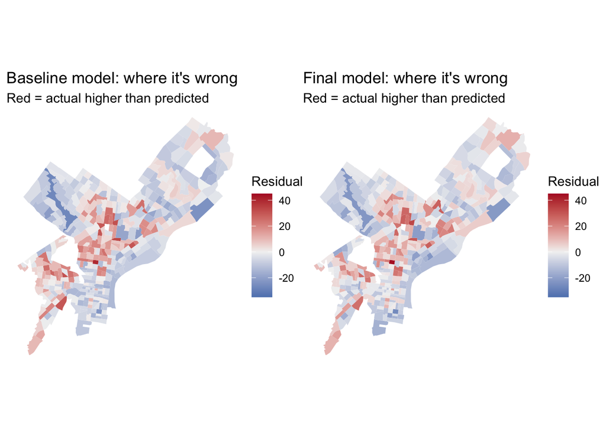

```r
tracts <- tracts %>% mutate(resid_final = residuals(m_final))

map_final <- ggplot(tracts) +
  geom_sf(aes(fill = resid_final), color = NA) +
  scale_fill_gradient2(low = "#2166ac", mid = "grey95", high = "#b2182b", midpoint = 0, limits = c(-35, 45)) +
  theme_void() +
  labs(title = "Final model: where it's wrong",
       subtitle = "Red = actual higher than predicted",
       fill = "Residual")

library(patchwork)
map_baseline + map_final
```

### Are the biggest misses in the least reliable tracts?

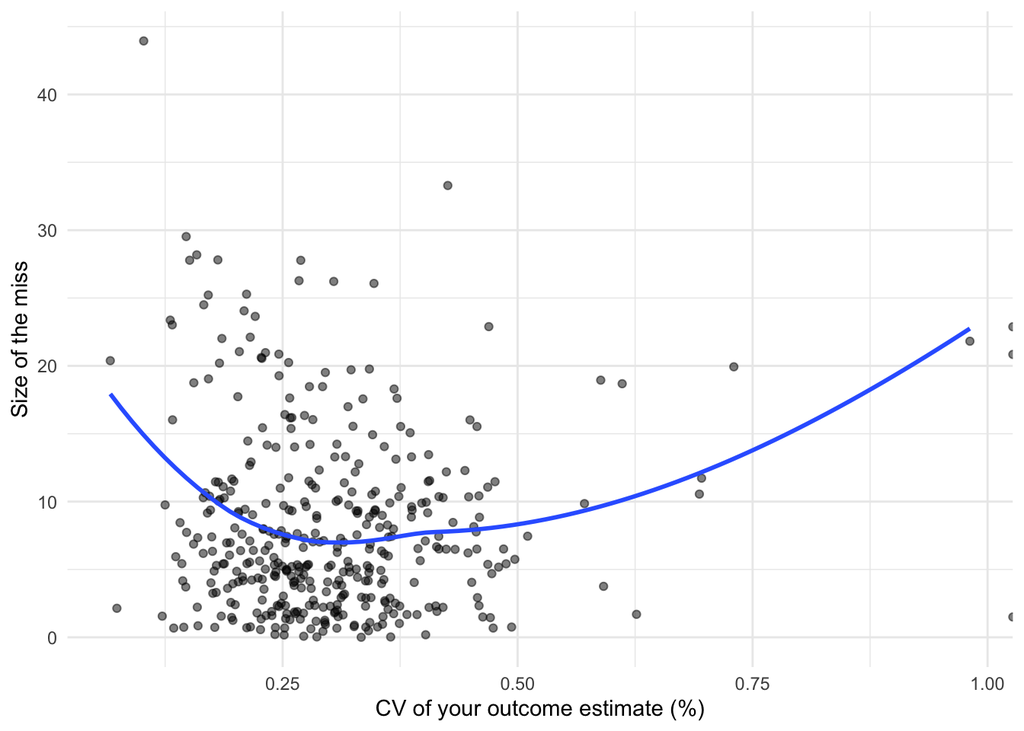

```r
ggplot(tracts, aes(x = y_cv, y = abs(resid_final))) +
  geom_point(alpha = 0.5) +
  geom_smooth(se = FALSE) +
  labs(x = "CV of your outcome estimate (%)", y = "Size of the miss") +
  theme_minimal()
```

## Part 7: Reflection

The feature that helped the most is the distance rings (core, inner, outer). They lowering the CV RMSE from 11.35 for the baseline to 10.86. Poverty is highest in the inner ring and lower in the core and outer areas, and rings capture better than the original variable distance to city hall. The feature that disappointed me most was theft density. Taking its log left the error at 11.35, the same as the baseline. Theft is high in Center City might be because of shoppers and tourists, not because residents are poor. The final model, which added thefts and bus stops, reached 10.87, so it is no better than the rings alone.

The coefficient for median age in the final model is -0.320. The β̂ reading is that, holding the other variables constant, each extra year of median age is associated with a 0.32 percentage point lower poverty rate. The ŷ reading is that if two similar tracts differ by 10 years in median age, the model predicts the older tract to have a poverty rate about 3.2 points lower.

The final residual map still shows red clusters in north and west Philadelphia, almost the same as the baseline. Next, I would measure housing, such as renter share, vacant buildings, and subsidized housing. Renter share is available in the ACS, and vacancy and property data are available from OpenDataPhilly.

The last plot shows that a reliable ACS number does not always mean a small miss. Some tracts with a low CV still have misses of 20 points or more, that means the model might missing something important about those areas, like housing or jobs, and it is not just a survey mistake. Tracts with a very high CV also have bigger misses, so some of that error may come from an uncertain ACS number.